# Content

1. Definition Problem
2. Importing Libraries
3. Data Collection
4. Data Overview
5. Data Cleaning
6. Exploratory Data Analysis
7. Feature Engineering
8. Data Modeling
9. Result

# 1. Definition Problem

The prediction task is to determine whether a person makes over $50K a year. [Dataset](https://archive.ics.uci.edu/ml/datasets/adult)

# 2. Importing Libraries

```python
import pandas as pd
import numpy as np

from sklearn.model_selection import train_test_split, cross_val_score, GridSearchCV
from sklearn.preprocessing import StandardScaler, OneHotEncoder, OrdinalEncoder, FunctionTransformer
from sklearn.pipeline import Pipeline, FeatureUnion
from sklearn.metrics import accuracy_score, confusion_matrix, classification_report
from sklearn.metrics import roc_auc_score, roc_curve, precision_recall_curve, euclidean_distances

from sklearn.linear_model import RidgeClassifier, SGDClassifier, LogisticRegression
from sklearn.svm import LinearSVC, SVC
from sklearn.neighbors import KNeighborsClassifier
from sklearn.tree import DecisionTreeClassifier
from sklearn.ensemble import RandomForestClassifier
from xgboost import XGBClassifier

import matplotlib.pyplot as plt
import seaborn as sns
```

```python
sns.set()
```

# 3. Data Collection

```python
data = pd.read_csv('adult.csv', sep=',')
```

# 4. Data Overview

## Data dictionary

- `age`: continuous.
- `workclass`: Private, Self-emp-not-inc, Self-emp-inc, Federal-gov, Local-gov, State-gov, Without-pay, Never-worked.
- `fnlwgt`: continuous.
- `education`: Bachelors, Some-college, 11th, HS-grad, Prof-school, Assoc-acdm, Assoc-voc, 9th, 7th-8th, 12th, Masters, 1st-4th, 10th, Doctorate, 5th-6th, Preschool.
- `education.num`: continuous.
- `marital.status`: Married-civ-spouse, Divorced, Never-married, Separated, Widowed, Married-spouse-absent, Married-AF-spouse.
- `occupation`: Tech-support, Craft-repair, Other-service, Sales, Exec-managerial, Prof-specialty, Handlers-cleaners, Machine-op-inspct, Adm-clerical, Farming-fishing, Transport-moving, Priv-house-serv, Protective-serv, Armed-Forces.
- `relationship`: Wife, Own-child, Husband, Not-in-family, Other-relative, Unmarried.
- `race`: White, Asian-Pac-Islander, Amer-Indian-Eskimo, Other, Black.
- `sex`: Female, Male.
- `capital.gain`: continuous.
- `capital.loss`: continuous.
- `hours.per.week`: continuous.
- `native.country`: United-States, Cambodia, England, Puerto-Rico, Canada, Germany, Outlying-US(Guam-USVI-etc), India, Japan, Greece, South, China, Cuba, Iran, Honduras, Philippines, Italy, Poland, Jamaica, Vietnam, Mexico, Portugal, Ireland, France, Dominican-Republic, Laos, Ecuador, Taiwan, Haiti, Columbia, Hungary, Guatemala, Nicaragua, Scotland, Thailand, Yugoslavia, El-Salvador, Trinadad&Tobago, Peru, Hong, Holand-Netherlands.
- There are 32561 instances and 15 features in the dataset.

```python
data.shape
```

```
(32561, 15)
```

```python
data.head()
```

|  | age | workclass | fnlwgt | education | education.num | marital.status | occupation | relationship | race | sex | capital.gain | capital.loss | hours.per.week | native.country | income |
| --- | --- | --- | --- | --- | --- | --- | --- | --- | --- | --- | --- | --- | --- | --- | --- |
| 0 | 90 | ? | 77053 | HS-grad | 9 | Widowed | ? | Not-in-family | White | Female | 0 | 4356 | 40 | United-States | <=50K |
| 1 | 82 | Private | 132870 | HS-grad | 9 | Widowed | Exec-managerial | Not-in-family | White | Female | 0 | 4356 | 18 | United-States | <=50K |
| 2 | 66 | ? | 186061 | Some-college | 10 | Widowed | ? | Unmarried | Black | Female | 0 | 4356 | 40 | United-States | <=50K |
| 3 | 54 | Private | 140359 | 7th-8th | 4 | Divorced | Machine-op-inspct | Unmarried | White | Female | 0 | 3900 | 40 | United-States | <=50K |
| 4 | 41 | Private | 264663 | Some-college | 10 | Separated | Prof-specialty | Own-child | White | Female | 0 | 3900 | 40 | United-States | <=50K |

```python
data.tail()
```

|  | age | workclass | fnlwgt | education | education.num | marital.status | occupation | relationship | race | sex | capital.gain | capital.loss | hours.per.week | native.country | income |
| --- | --- | --- | --- | --- | --- | --- | --- | --- | --- | --- | --- | --- | --- | --- | --- |
| 32556 | 22 | Private | 310152 | Some-college | 10 | Never-married | Protective-serv | Not-in-family | White | Male | 0 | 0 | 40 | United-States | <=50K |
| 32557 | 27 | Private | 257302 | Assoc-acdm | 12 | Married-civ-spouse | Tech-support | Wife | White | Female | 0 | 0 | 38 | United-States | <=50K |
| 32558 | 40 | Private | 154374 | HS-grad | 9 | Married-civ-spouse | Machine-op-inspct | Husband | White | Male | 0 | 0 | 40 | United-States | >50K |
| 32559 | 58 | Private | 151910 | HS-grad | 9 | Widowed | Adm-clerical | Unmarried | White | Female | 0 | 0 | 40 | United-States | <=50K |
| 32560 | 22 | Private | 201490 | HS-grad | 9 | Never-married | Adm-clerical | Own-child | White | Male | 0 | 0 | 20 | United-States | <=50K |

```python
data.info()
```

```
<class 'pandas.core.frame.DataFrame'>
RangeIndex: 32561 entries, 0 to 32560
Data columns (total 15 columns):
 #   Column          Non-Null Count  Dtype
---  ------          --------------  -----
 0   age             32561 non-null  int64
 1   workclass       32561 non-null  object
 2   fnlwgt          32561 non-null  int64
 3   education       32561 non-null  object
 4   education.num   32561 non-null  int64
 5   marital.status  32561 non-null  object
 6   occupation      32561 non-null  object
 7   relationship    32561 non-null  object
 8   race            32561 non-null  object
 9   sex             32561 non-null  object
 10  capital.gain    32561 non-null  int64
 11  capital.loss    32561 non-null  int64
 12  hours.per.week  32561 non-null  int64
 13  native.country  32561 non-null  object
 14  income          32561 non-null  object
dtypes: int64(6), object(9)
memory usage: 3.7+ MB
```

```python
data.describe()
```

|  | age | fnlwgt | education.num | capital.gain | capital.loss | hours.per.week |
| --- | --- | --- | --- | --- | --- | --- |
| count | 32561.000000 | 3.256100e+04 | 32561.000000 | 32561.000000 | 32561.000000 | 32561.000000 |
| mean | 38.581647 | 1.897784e+05 | 10.080679 | 1077.648844 | 87.303830 | 40.437456 |
| std | 13.640433 | 1.055500e+05 | 2.572720 | 7385.292085 | 402.960219 | 12.347429 |
| min | 17.000000 | 1.228500e+04 | 1.000000 | 0.000000 | 0.000000 | 1.000000 |
| 25% | 28.000000 | 1.178270e+05 | 9.000000 | 0.000000 | 0.000000 | 40.000000 |
| 50% | 37.000000 | 1.783560e+05 | 10.000000 | 0.000000 | 0.000000 | 40.000000 |
| 75% | 48.000000 | 2.370510e+05 | 12.000000 | 0.000000 | 0.000000 | 45.000000 |
| max | 90.000000 | 1.484705e+06 | 16.000000 | 99999.000000 | 4356.000000 | 99.000000 |

```python
data.describe(include=['object'])
```

|  | workclass | education | marital.status | occupation | relationship | race | sex | native.country | income |
| --- | --- | --- | --- | --- | --- | --- | --- | --- | --- |
| count | 32561 | 32561 | 32561 | 32561 | 32561 | 32561 | 32561 | 32561 | 32561 |
| unique | 9 | 16 | 7 | 15 | 6 | 5 | 2 | 42 | 2 |
| top | Private | HS-grad | Married-civ-spouse | Prof-specialty | Husband | White | Male | United-States | <=50K |
| freq | 22696 | 10501 | 14976 | 4140 | 13193 | 27816 | 21790 | 29170 | 24720 |

# 5. Data Cleaning

## 5.1. Duplicate Data

- 24 rows are duplicated.

```python
data.duplicated().sum()
```

```
24
```

- 22 rows are duplicated with income `<=50K`.
- 2 rows rows are duplicated with income `>50K`.

```python
data[data.duplicated()]['income'].value_counts()
```

```
<=50K    22
>50K      2
Name: income, dtype: int64
```

- Can be deleted duplicate data because there are few of them.

```python
data.drop_duplicates(inplace=True)
```

## 5.2. Incorrect Data

- All values are correctly filled among the numerical data.

```python
data[['age', 'education.num']].applymap(lambda v: v > 0).all(axis=0)
```

```
age              True
education.num    True
dtype: bool
```

```python
data[['fnlwgt', 'capital.gain', 'capital.loss', 'hours.per.week']].applymap(lambda v: v >= 0).all(axis=0)
```

```
fnlwgt            True
capital.gain      True
capital.loss      True
hours.per.week    True
dtype: bool
```

- All values are correctly filled among the categorical data.

```python
data.select_dtypes(include=['object']).apply(lambda s: s.str.match(r'\s+')).any(axis=0)
```

```
workclass         False
education         False
marital.status    False
occupation        False
relationship      False
race              False
sex               False
native.country    False
income            False
dtype: bool
```

## 5.3. Missing Data

- Unknown information is denoted by `?`.

```python
data.replace(to_replace='?', value=np.nan, inplace=True)
```

```python
data.info()
```

```
<class 'pandas.core.frame.DataFrame'>
Int64Index: 32537 entries, 0 to 32560
Data columns (total 15 columns):
 #   Column          Non-Null Count  Dtype
---  ------          --------------  -----
 0   age             32537 non-null  int64
 1   workclass       30701 non-null  object
 2   fnlwgt          32537 non-null  int64
 3   education       32537 non-null  object
 4   education.num   32537 non-null  int64
 5   marital.status  32537 non-null  object
 6   occupation      30694 non-null  object
 7   relationship    32537 non-null  object
 8   race            32537 non-null  object
 9   sex             32537 non-null  object
 10  capital.gain    32537 non-null  int64
 11  capital.loss    32537 non-null  int64
 12  hours.per.week  32537 non-null  int64
 13  native.country  31955 non-null  object
 14  income          32537 non-null  object
dtypes: int64(6), object(9)
memory usage: 4.0+ MB
```

- Percentage of unknown information among the features is small or equals to zero.

```python
for column in data.columns[data.dtypes == 'object'].values:
    print(f"{column}: {(data[column].isna()).sum() / data.shape[0] * 100:.3f}%")
```

```
workclass: 5.643%
education: 0.000%
marital.status: 0.000%
occupation: 5.664%
relationship: 0.000%
race: 0.000%
sex: 0.000%
native.country: 1.789%
income: 0.000%
```

- Can be filled missing data for categorical features with their mode.

```python
cat_columns = data.select_dtypes('object').columns.values
for column in cat_columns:
    data[column].fillna(value=data[column].mode()[0], inplace=True)
```

# 6. Exploratory Data Analysis

```python
data.head()
```

|  | age | workclass | fnlwgt | education | education.num | marital.status | occupation | relationship | race | sex | capital.gain | capital.loss | hours.per.week | native.country | income |
| --- | --- | --- | --- | --- | --- | --- | --- | --- | --- | --- | --- | --- | --- | --- | --- |
| 0 | 90 | Private | 77053 | HS-grad | 9 | Widowed | Prof-specialty | Not-in-family | White | Female | 0 | 4356 | 40 | United-States | <=50K |
| 1 | 82 | Private | 132870 | HS-grad | 9 | Widowed | Exec-managerial | Not-in-family | White | Female | 0 | 4356 | 18 | United-States | <=50K |
| 2 | 66 | Private | 186061 | Some-college | 10 | Widowed | Prof-specialty | Unmarried | Black | Female | 0 | 4356 | 40 | United-States | <=50K |
| 3 | 54 | Private | 140359 | 7th-8th | 4 | Divorced | Machine-op-inspct | Unmarried | White | Female | 0 | 3900 | 40 | United-States | <=50K |
| 4 | 41 | Private | 264663 | Some-college | 10 | Separated | Prof-specialty | Own-child | White | Female | 0 | 3900 | 40 | United-States | <=50K |

## 6.1. Income

- People who earn `<=50K` are approximately three times more than those who earn `>50K`.

```python
income_count = data['income'].value_counts()
income_percent = data['income'].value_counts(normalize=True)

pd.concat([income_count, income_percent], axis=1, keys=['count', 'percent'])
```

|  | count | percent |
| --- | --- | --- |
| <=50K | 24698 | 0.759074 |
| >50K | 7839 | 0.240926 |

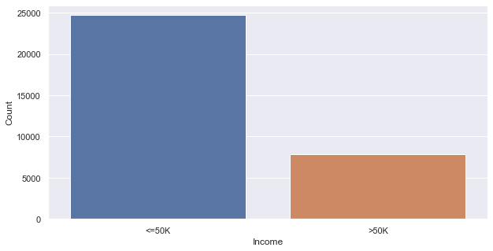

```python
plt.figure(figsize=(10, 5))
sns.countplot(x='income', data=data)

plt.xlabel('Income')
plt.ylabel('Count');
```

## 6.2. Age

- Majority of people belong to age group approximately from `17` to `46` years.

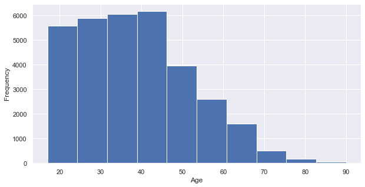

```python
plt.figure(figsize=(10, 5))
plt.hist(data['age'])

plt.xlabel('Age')
plt.ylabel('Frequency');
```

```python
data[['age']].describe()
```

|  | age |
| --- | --- |
| count | 32537.000000 |
| mean | 38.585549 |
| std | 13.637984 |
| min | 17.000000 |
| 25% | 28.000000 |
| 50% | 37.000000 |
| 75% | 48.000000 |
| max | 90.000000 |

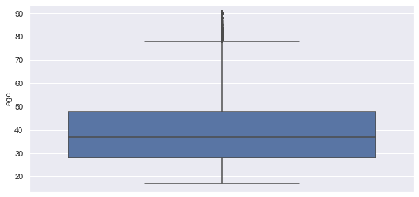

```python
plt.figure(figsize=(10, 5))
sns.boxplot(y='age', data=data);
```

## 6.3. Age & Income

- Majority of people who earn `<=50K` belong to age group approximately from `17` to `39` years.
- Majority of people who earn `>50K` belong to age group approximately from `33` to `55` years.

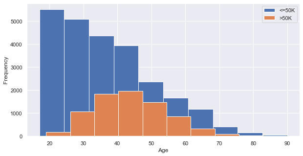

```python
plt.figure(figsize=(10, 5))
plt.hist(data.loc[data['income'] == '<=50K', 'age'], label='<=50K')
plt.hist(data.loc[data['income'] == '>50K', 'age'], label='>50K')

plt.xlabel('Age')
plt.ylabel('Frequency')
plt.legend();
```

- Average age of people who earn `>50K` is larger than those who earn `<=50K`.

```python
data.groupby(by='income')['age'].describe().T
```

| income | <=50K | >50K |
| --- | --- | --- |
| count | 24698.000000 | 7839.000000 |
| mean | 36.787392 | 44.250925 |
| std | 14.017335 | 10.520102 |
| min | 17.000000 | 19.000000 |
| 25% | 25.000000 | 36.000000 |
| 50% | 34.000000 | 44.000000 |
| 75% | 46.000000 | 51.000000 |
| max | 90.000000 | 90.000000 |

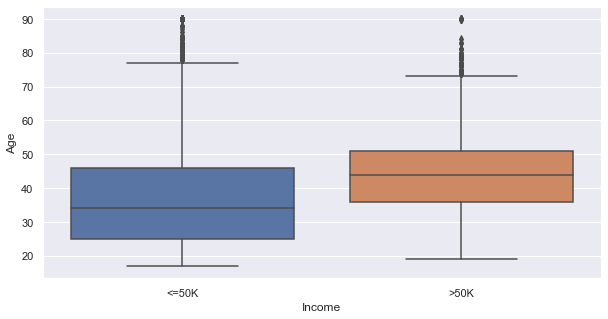

```python
plt.figure(figsize=(10, 5))
sns.boxplot(x='income', y='age', data=data)

plt.xlabel('Income')
plt.ylabel('Age');
```

## 6.4. Work class

- Majority of people belong to `Private` work class.
- There are few of people who belong to such work classes as `Without-pay` and `Never-worked`.

```python
data['workclass'].value_counts()
```

```
Private             24509
Self-emp-not-inc     2540
Local-gov            2093
State-gov            1298
Self-emp-inc         1116
Federal-gov           960
Without-pay            14
Never-worked            7
Name: workclass, dtype: int64
```

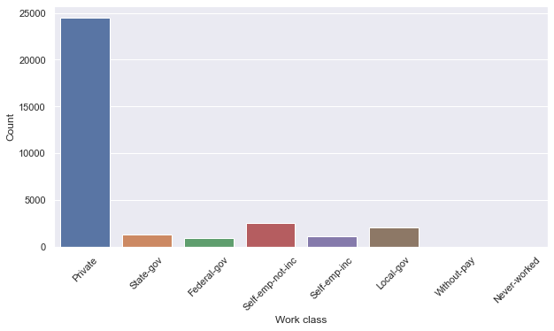

```python
plt.figure(figsize=(10, 5))
sns.countplot(x='workclass', data=data)

plt.xlabel("Work class")
plt.ylabel('Count')
plt.xticks(rotation=45);
```

## 6.5. Work class & Income

- Majority of people earn `<=50K` in every category of work class except `Self-emp-inc`.
- Well, clearly people don't earn who belong to `Never-worked` work class.
- No one earns `>50K` among those who belong to `Without-pay` work class.

```python
tab = pd.crosstab(data['workclass'], data['income'], normalize='index')
tab
```

| income workclass | <=50K | >50K |
| --- | --- | --- |
| Federal-gov | 0.613542 | 0.386458 |
| Local-gov | 0.705208 | 0.294792 |
| Never-worked | 1.000000 | 0.000000 |
| Private | 0.789792 | 0.210208 |
| Self-emp-inc | 0.442652 | 0.557348 |
| Self-emp-not-inc | 0.714961 | 0.285039 |
| State-gov | 0.728043 | 0.271957 |
| Without-pay | 1.000000 | 0.000000 |

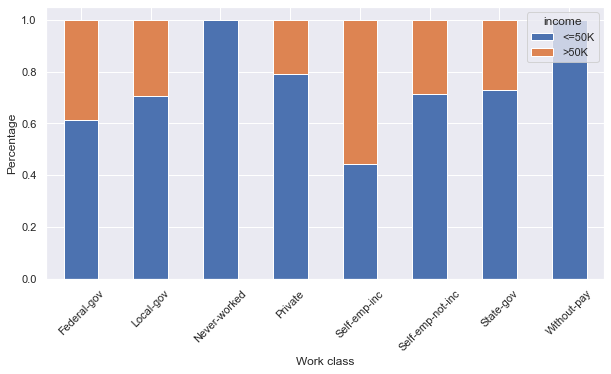

```python
tab.plot(kind='bar', stacked=True, figsize=(10, 5))

plt.xlabel("Work class")
plt.ylabel('Percentage')
plt.xticks(rotation=45);
```

- Can be combined `Without-pay` and `Never-worked` in one group called `Other`.
- People who work in the government are divided into `federal`, `state`, and `local` levels. Them can be combined in group called `Government`.
- People who are self-employed are divided into `incorporated` and `not incorporated`. Them can be combined in one group called `Self-Employed`.

```python
new_data = data.copy()
```

```python
new_data['workclass'].replace(to_replace=['Without-pay', 'Never-worked', 'Unknown'], value='Other', inplace=True)
new_data.loc[new_data['workclass'].isin(['Federal-gov', 'Local-gov', 'State-gov']), 'workclass'] = 'Government'
new_data.loc[new_data['workclass'].str.startswith('Self-emp'), 'workclass'] = 'Self-employed'
```

- `Self-employed` work class have the highest percentage of people who earn `>50K`.

```python
tab = pd.crosstab(new_data['workclass'], new_data['income'], normalize='index')
tab
```

| income workclass | <=50K | >50K |
| --- | --- | --- |
| Government | 0.691795 | 0.308205 |
| Other | 1.000000 | 0.000000 |
| Private | 0.789792 | 0.210208 |
| Self-employed | 0.631838 | 0.368162 |

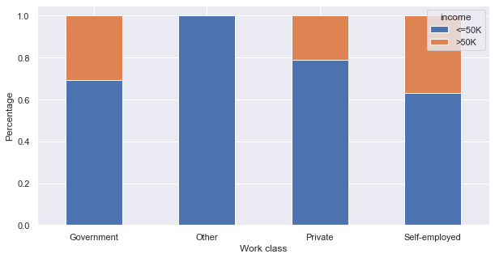

```python
tab.plot(kind='bar', stacked=True, figsize=(10, 5))

plt.xlabel("Work class")
plt.ylabel('Percentage')
plt.xticks(rotation=0);
```

## 6.6. Final weight

- Majority of people have a final weight approximately from `12000` to `307000`.

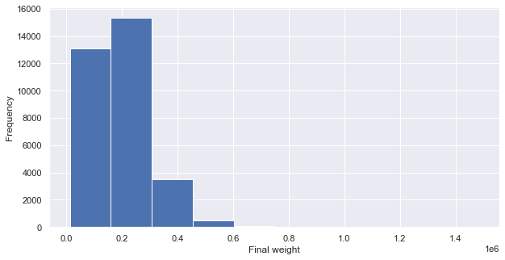

```python
plt.figure(figsize=(10, 5))
plt.hist(data['fnlwgt'])

plt.xlabel("Final weight")
plt.ylabel('Frequency');
```

```python
data[['fnlwgt']].describe()
```

|  | fnlwgt |
| --- | --- |
| count | 3.253700e+04 |
| mean | 1.897808e+05 |
| std | 1.055565e+05 |
| min | 1.228500e+04 |
| 25% | 1.178270e+05 |
| 50% | 1.783560e+05 |
| 75% | 2.369930e+05 |
| max | 1.484705e+06 |

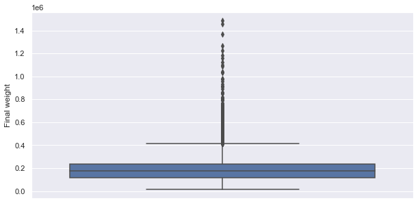

```python
plt.figure(figsize=(10, 5))
sns.boxplot(y='fnlwgt', data=data)

plt.ylabel("Final weight");
```

## 6.7. Final weight & Income

- Majority of people who earn `<=50K` have a final weight approximately from `12000` to `307000`.
- Majority of people who earn `>50K` have a final weight approximately from `15000` to `257000`.

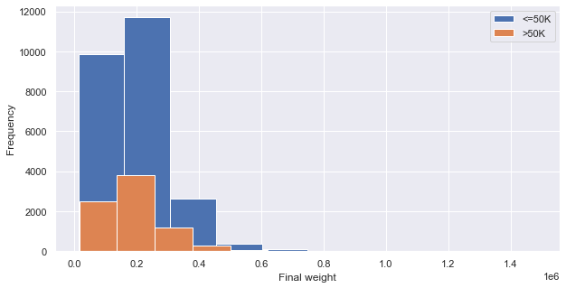

```python
plt.figure(figsize=(10, 5))
plt.hist(data.loc[data['income'] == '<=50K', 'fnlwgt'], label='<=50K')
plt.hist(data.loc[data['income'] == '>50K', 'fnlwgt'], label='>50K')

plt.xlabel("Final weight")
plt.ylabel('Frequency')
plt.legend();
```

- Average final weight is about the same, regardless of people's income.

```python
data.groupby(by='income')['fnlwgt'].describe().T
```

| income | <=50K | >50K |
| --- | --- | --- |
| count | 2.469800e+04 | 7.839000e+03 |
| mean | 1.903459e+05 | 1.880005e+05 |
| std | 1.064874e+05 | 1.025545e+05 |
| min | 1.228500e+04 | 1.487800e+04 |
| 25% | 1.176060e+05 | 1.191000e+05 |
| 50% | 1.794650e+05 | 1.760630e+05 |
| 75% | 2.389682e+05 | 2.309690e+05 |
| max | 1.484705e+06 | 1.226583e+06 |

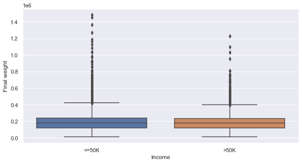

```python
plt.figure(figsize=(10, 5))
sns.boxplot(x='income', y='fnlwgt', data=data)

plt.xlabel('Income')
plt.ylabel("Final weight");
```

## 6.8. Education

- There are many people in such categories of education as `HS-grad`, `Some-college`, and `Bachelors`.
- There aren't many people who have `Doctorate` education.

```python
data['education'].value_counts()
```

```
HS-grad         10494
Some-college     7282
Bachelors        5353
Masters          1722
Assoc-voc        1382
11th             1175
Assoc-acdm       1067
10th              933
7th-8th           645
Prof-school       576
9th               514
12th              433
Doctorate         413
5th-6th           332
1st-4th           166
Preschool          50
Name: education, dtype: int64
```

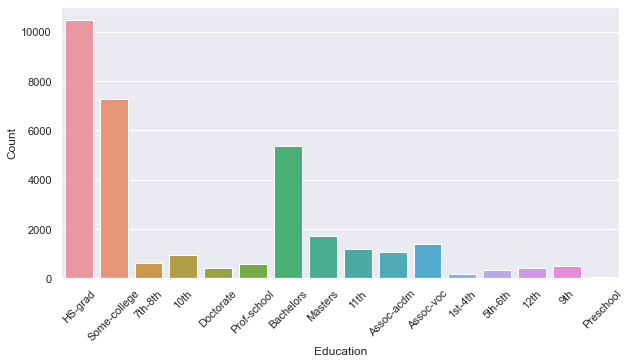

```python
plt.figure(figsize=(10, 5))
sns.countplot(x='education', data=data)

plt.xlabel('Education')
plt.ylabel('Count')
plt.xticks(rotation=45);
```

## 6.9. Education & Income

- Majority of people earn `>50K` in such categories of education as `Doctorate`, `Masters`, and `Prof-school`.
- Can be noticed that percentage of those who earn `>50K` decreases as the years of education decrease.

```python
tab = pd.crosstab(data['education'], data['income'], normalize='index')
tab
```

| income education | <=50K | >50K |
| --- | --- | --- |
| 10th | 0.933548 | 0.066452 |
| 11th | 0.948936 | 0.051064 |
| 12th | 0.923788 | 0.076212 |
| 1st-4th | 0.963855 | 0.036145 |
| 5th-6th | 0.951807 | 0.048193 |
| 7th-8th | 0.937984 | 0.062016 |
| 9th | 0.947471 | 0.052529 |
| Assoc-acdm | 0.751640 | 0.248360 |
| Assoc-voc | 0.738784 | 0.261216 |
| Bachelors | 0.585092 | 0.414908 |
| Doctorate | 0.259080 | 0.740920 |
| HS-grad | 0.840480 | 0.159520 |
| Masters | 0.443089 | 0.556911 |
| Preschool | 1.000000 | 0.000000 |
| Prof-school | 0.265625 | 0.734375 |
| Some-college | 0.809668 | 0.190332 |

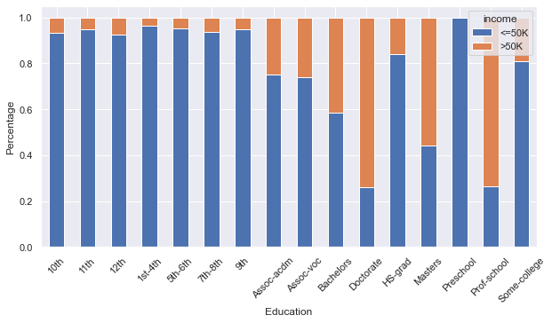

```python
tab.plot(kind='bar', stacked=True, figsize=(10, 5))

plt.xlabel('Education')
plt.ylabel('Percentage')
plt.xticks(rotation=45);
```

## 6.10. Education number

- There are many people with such education numbers as `9`, `10`, and `13`.
- There aren't many people who have `16` education number.

```python
data['education.num'].value_counts()
```

```
9     10494
10     7282
13     5353
14     1722
11     1382
7      1175
12     1067
6       933
4       645
15      576
5       514
8       433
16      413
3       332
2       166
1        50
Name: education.num, dtype: int64
```

- Average education number of people is `10`.

```python
data[['education.num']].describe()
```

|  | education.num |
| --- | --- |
| count | 32537.000000 |
| mean | 10.081815 |
| std | 2.571633 |
| min | 1.000000 |
| 25% | 9.000000 |
| 50% | 10.000000 |
| 75% | 12.000000 |
| max | 16.000000 |

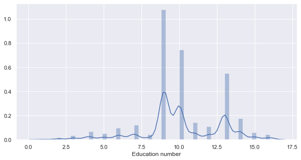

```python
plt.figure(figsize=(10, 5))
sns.distplot(data['education.num'])

plt.xlabel("Education number");
```

## 6.11. Education number & Income

- Majority of people earn `>50K` with such education numbers as `14`, `15`, and `16`.
- Can be noticed that amount of those who earn `>50K` decreases as the years of education decrease.

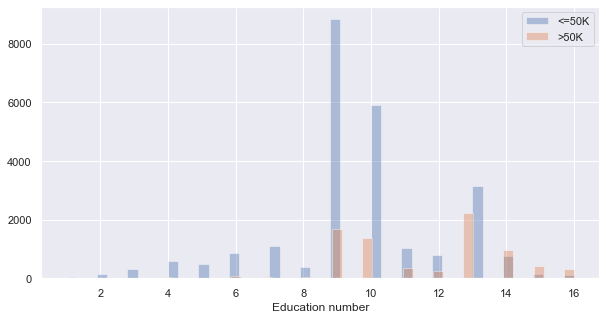

```python
plt.figure(figsize=(10, 5))
sns.distplot(data.loc[data['income'] == '<=50K', 'education.num'], kde=False, label='<=50K')
sns.distplot(data.loc[data['income'] == '>50K', 'education.num'], kde=False, label='>50K')

plt.xlabel("Education number")
plt.legend();
```

- Average education number of people who earn `>50K` is larger than those who earn `<=50K`.

```python
data.groupby(by='income')['education.num'].describe().T
```

| income | <=50K | >50K |
| --- | --- | --- |
| count | 24698.000000 | 7839.000000 |
| mean | 9.596081 | 11.612195 |
| std | 2.434654 | 2.385181 |
| min | 1.000000 | 2.000000 |
| 25% | 9.000000 | 10.000000 |
| 50% | 9.000000 | 12.000000 |
| 75% | 10.000000 | 13.000000 |
| max | 16.000000 | 16.000000 |

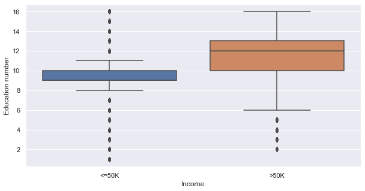

```python
plt.figure(figsize=(10, 5))
sns.boxplot(x='income', y='education.num', data=data)

plt.xlabel('Income')
plt.ylabel("Education number");
```

## 6.12. Marital status

- Most of people have `Married-civ-spouse` or `Never-married` marital status.
- Can be observed many `Divorced` marital status.

```python
data['marital.status'].value_counts()
```

```
Married-civ-spouse       14970
Never-married            10667
Divorced                  4441
Separated                 1025
Widowed                    993
Married-spouse-absent      418
Married-AF-spouse           23
Name: marital.status, dtype: int64
```

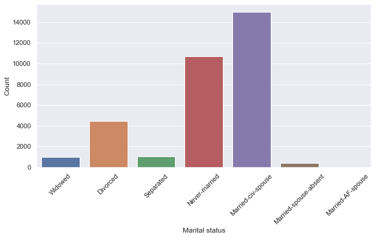

```python
plt.figure(figsize=(10, 5))
sns.countplot(x='marital.status', data=data)

plt.xlabel("Marital status")
plt.ylabel('Count')
plt.xticks(rotation=45);
```

## 6.13. Marital status & Income

```python
tab = pd.crosstab(data['marital.status'], data['income'], normalize='index')
tab
```

| income marital.status | <=50K | >50K |
| --- | --- | --- |
| Divorced | 0.895744 | 0.104256 |
| Married-AF-spouse | 0.565217 | 0.434783 |
| Married-civ-spouse | 0.553106 | 0.446894 |
| Married-spouse-absent | 0.918660 | 0.081340 |
| Never-married | 0.953970 | 0.046030 |
| Separated | 0.935610 | 0.064390 |
| Widowed | 0.914401 | 0.085599 |

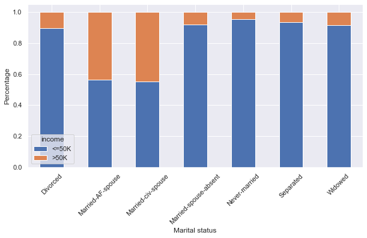

```python
tab.plot(kind='bar', stacked=True, figsize=(10, 5))

plt.xlabel("Marital status")
plt.ylabel('Percentage')
plt.xticks(rotation=45);
```

- Can be combined in one group called `Married` such categories of marital status as `Married-AF-spouse`, `Married-civ-spouse`, and `Married-spouse-absent`.

```python
new_data['marital.status'].replace(to_replace=['Married-AF-spouse', 'Married-civ-spouse', 'Married-spouse-absent'],
                                   value='Married', inplace=True)
```

- Marital status such as `Married` have the highest percentage of those who earn `>50`.

```python
tab = pd.crosstab(new_data['marital.status'], new_data['income'], normalize='index')
tab
```

| income marital.status | <=50K | >50K |
| --- | --- | --- |
| Divorced | 0.895744 | 0.104256 |
| Married | 0.563039 | 0.436961 |
| Never-married | 0.953970 | 0.046030 |
| Separated | 0.935610 | 0.064390 |
| Widowed | 0.914401 | 0.085599 |

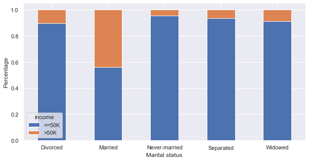

```python
tab.plot(kind='bar', stacked=True, figsize=(10, 5))

plt.xlabel("Marital status")
plt.ylabel('Percentage')
plt.xticks(rotation=0);
```

## 6.14. Occupation

- Among people, the most popular occupations are `Prof-specialty`, `Craft-repair`, and `Exec-managerial`.
- Occupation such as `Armed-Forces` isn't popular.

```python
data['occupation'].value_counts()
```

```
Prof-specialty       5979
Craft-repair         4094
Exec-managerial      4065
Adm-clerical         3768
Sales                3650
Other-service        3291
Machine-op-inspct    2000
Transport-moving     1597
Handlers-cleaners    1369
Farming-fishing       992
Tech-support          927
Protective-serv       649
Priv-house-serv       147
Armed-Forces            9
Name: occupation, dtype: int64
```

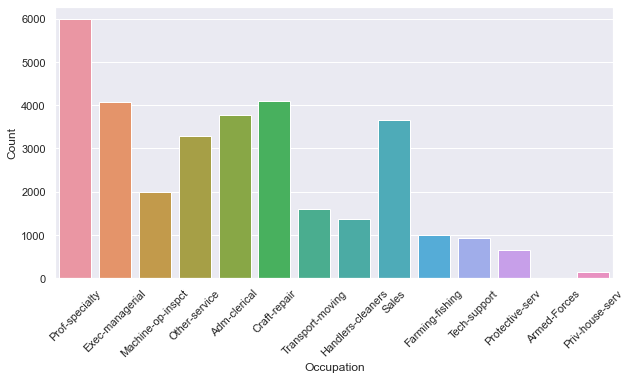

```python
plt.figure(figsize=(10, 5))
sns.countplot(x='occupation', data=data)

plt.xlabel('Occupation')
plt.ylabel('Count')
plt.xticks(rotation=45);
```

## 6.15. Occupation & Income

```python
tab = pd.crosstab(data['occupation'], data['income'], normalize='index')
tab
```

| income occupation | <=50K | >50K |
| --- | --- | --- |
| Adm-clerical | 0.865446 | 0.134554 |
| Armed-Forces | 0.888889 | 0.111111 |
| Craft-repair | 0.773083 | 0.226917 |
| Exec-managerial | 0.515867 | 0.484133 |
| Farming-fishing | 0.884073 | 0.115927 |
| Handlers-cleaners | 0.937180 | 0.062820 |
| Machine-op-inspct | 0.875500 | 0.124500 |
| Other-service | 0.958371 | 0.041629 |
| Priv-house-serv | 0.993197 | 0.006803 |
| Prof-specialty | 0.657301 | 0.342699 |
| Protective-serv | 0.674884 | 0.325116 |
| Sales | 0.730685 | 0.269315 |
| Tech-support | 0.694714 | 0.305286 |
| Transport-moving | 0.799624 | 0.200376 |

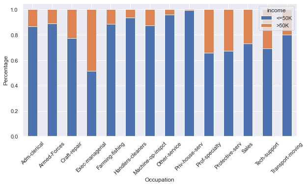

```python
tab.plot(kind='bar', stacked=True, figsize=(10, 5))

plt.xlabel('Occupation')
plt.ylabel('Percentage')
plt.xticks(rotation=45);
```

## 6.16. Relationship

- A lot of people have a role in the family as `Husband`.
- Number of relationship `Not-in-family` is large enough.

```python
data['relationship'].value_counts()
```

```
Husband           13187
Not-in-family      8292
Own-child          5064
Unmarried          3445
Wife               1568
Other-relative      981
Name: relationship, dtype: int64
```

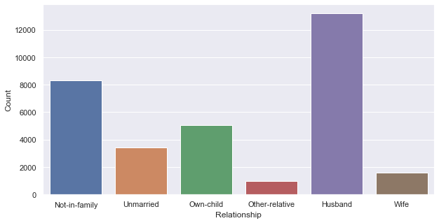

```python
plt.figure(figsize=(10, 5))
sns.countplot(x='relationship', data=data)

plt.xlabel('Relationship')
plt.ylabel('Count');
```

## 6.17. Relationship & Income

```python
tab = pd.crosstab(data['relationship'], data['income'], normalize='index')
tab
```

| income relationship | <=50K | >50K |
| --- | --- | --- |
| Husband | 0.551376 | 0.448624 |
| Not-in-family | 0.896768 | 0.103232 |
| Other-relative | 0.962283 | 0.037717 |
| Own-child | 0.986769 | 0.013231 |
| Unmarried | 0.936720 | 0.063280 |
| Wife | 0.524872 | 0.475128 |

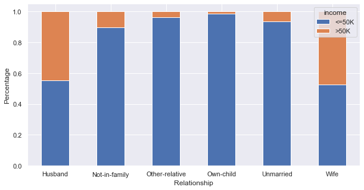

```python
tab.plot(kind='bar', stacked=True, figsize=(10, 5))

plt.xlabel('Relationship')
plt.ylabel('Percentage')
plt.xticks(rotation=0);
```

## 6.18. Race

- Quite many people are `White` race.
- Can be noticed few people are `Amer-Indian-Eskimo` or `Other` race.

```python
data['race'].value_counts()
```

```
White                 27795
Black                  3122
Asian-Pac-Islander     1038
Amer-Indian-Eskimo      311
Other                   271
Name: race, dtype: int64
```

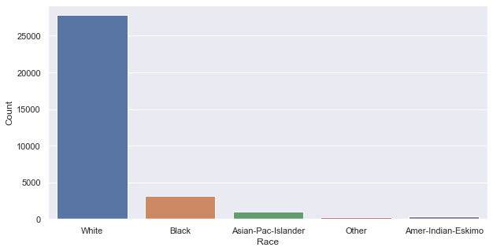

```python
plt.figure(figsize=(10, 5))
sns.countplot(x='race', data=data)

plt.xlabel('Race')
plt.ylabel('Count');
```

## 6.19. Race & Income

- Majority of people earn `<=50K` in every category of race.
- People who are `White` or `Asian-Pac-Islander` have the highest percentage of those who earn `>50`.

```python
tab = pd.crosstab(data['race'], data['income'], normalize='index')
tab
```

| income race | <=50K | >50K |
| --- | --- | --- |
| Amer-Indian-Eskimo | 0.884244 | 0.115756 |
| Asian-Pac-Islander | 0.734104 | 0.265896 |
| Black | 0.876041 | 0.123959 |
| Other | 0.907749 | 0.092251 |
| White | 0.744019 | 0.255981 |

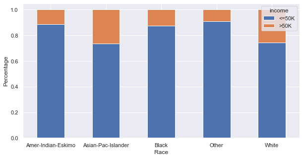

```python
tab.plot(kind='bar', stacked=True, figsize=(10, 5))

plt.xlabel('Race')
plt.ylabel('Percentage')
plt.xticks(rotation=0);
```

## 6.20. Sex

- Among people are more males than females.

```python
data['sex'].value_counts()
```

```
Male      21775
Female    10762
Name: sex, dtype: int64
```

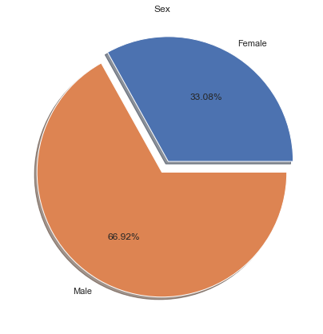

```python
plt.figure(figsize=(7, 10))
plt.pie(data['sex'].value_counts(ascending=True), explode=[0.1, 0], labels=data['sex'].unique(), autopct='%.2f%%', shadow=True)

plt.title('Sex');
```

## 6.21. Sex & Income

- Majority of males and females earn `<=50K`.

```python
tab = pd.crosstab(data['sex'], data['income'], normalize='index')
tab
```

| income sex | <=50K | >50K |
| --- | --- | --- |
| Female | 0.890448 | 0.109552 |
| Male | 0.694145 | 0.305855 |

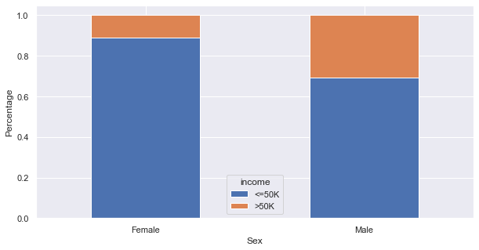

```python
tab.plot(kind='bar', stacked=True, figsize=(10, 5))

plt.xlabel('Sex')
plt.ylabel('Percentage')
plt.xticks(rotation=0);
```

## 6.22. Capital gain

- Quite many people have a capital gain equal to `zero`.

```python
data[['capital.gain']].describe()
```

|  | capital.gain |
| --- | --- |
| count | 32537.000000 |
| mean | 1078.443741 |
| std | 7387.957424 |
| min | 0.000000 |
| 25% | 0.000000 |
| 50% | 0.000000 |
| 75% | 0.000000 |
| max | 99999.000000 |

```python
data.loc[data['capital.gain'] == 0, 'capital.gain'].count()
```

```
29825
```

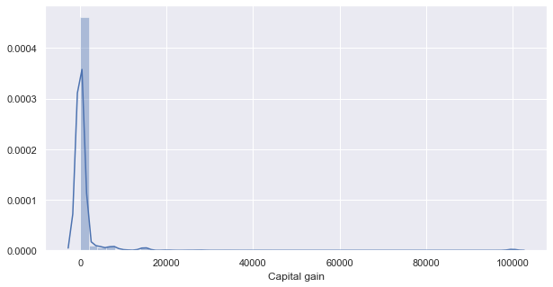

```python
plt.figure(figsize=(10, 5))
sns.distplot(data['capital.gain'])

plt.xlabel("Capital gain");
```

## 6.23. Capital gain & Income

- Quite many people who earn `<=50K` or `>50K` have a capital gain equal to `zero`.

```python
data.groupby(by='income')['capital.gain'].describe().T
```

| income | <=50K | >50K |
| --- | --- | --- |
| count | 24698.000000 | 7839.000000 |
| mean | 148.884970 | 4007.164562 |
| std | 963.557955 | 14572.097223 |
| min | 0.000000 | 0.000000 |
| 25% | 0.000000 | 0.000000 |
| 50% | 0.000000 | 0.000000 |
| 75% | 0.000000 | 0.000000 |
| max | 41310.000000 | 99999.000000 |

```python
data.loc[(data['capital.gain'] == 0) & (data['income'] == '<=50K'), 'capital.gain'].count()
```

```
23663
```

```python
data.loc[(data['capital.gain'] == 0) & (data['income'] == '>50K'), 'capital.gain'].count()
```

```
6162
```

- Capital gain of people who earn `>50K` is larger than those who earn `<=50K`.

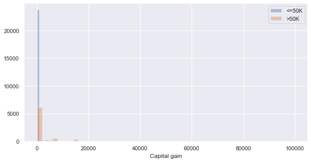

```python
plt.figure(figsize=(10, 5))
sns.distplot(data.loc[data['income'] == '<=50K', 'capital.gain'], kde=False, label='<=50K')
sns.distplot(data.loc[data['income'] == '>50K', 'capital.gain'], kde=False, label='>50K')

plt.xlabel("Capital gain");
plt.legend();
```